# Models for Football Data

# Data Overview

We load football data from a Kaggle containing 1st division Spanish League results (https://www.kaggle.com/datasets/ricardomoya/football-matches-of-spanish-league), for the 2016-17 and 2017-18 seasons.

```r
library("dplyr")
library("tidyr")
library("ggplot2")
library("reshape2")
library("nloptr")
library("data.table")

data <- read.csv("https://raw.githubusercontent.com/plamenapp/MastersThesis/master/FMEL_Dataset.csv")


data <- data %>%
  filter(season == "2016-17" | season == "2017-18" ) %>%
  filter(division == 1)

head(data)
```

|  | id | season | division | round | localTeam | visitorTeam | localGoals | visitorGoals | date | timestamp |
| --- | --- | --- | --- | --- | --- | --- | --- | --- | --- | --- |
| 1 | 35464 | 2016-17 | 1 | 1 | Malaga | Osasuna | 1 | 1 | 19/08/2016 | 1471557600 |
| 2 | 35465 | 2016-17 | 1 | 1 | Deportivo | Eibar | 2 | 1 | 19/08/2016 | 1471557600 |
| 3 | 35466 | 2016-17 | 1 | 1 | Barcelona | Betis | 6 | 2 | 20/08/2016 | 1471644000 |
| 4 | 35467 | 2016-17 | 1 | 1 | Granada | Villarreal | 1 | 1 | 20/08/2016 | 1471644000 |
| 5 | 35468 | 2016-17 | 1 | 1 | Sevilla | Espanol | 6 | 4 | 20/08/2016 | 1471644000 |
| 6 | 35469 | 2016-17 | 1 | 1 | Sporting de Gijon | Atletico de Bilbao | 2 | 1 | 21/08/2016 | 1471730400 |

Reshaping the data so that we have one team per row.

```r
melt_results <- function(results_df) {
  results_df %>%
    # select only relevant columns
    select(localTeam, visitorTeam, localGoals, visitorGoals, date) %>%
    gather(location, team,  -localGoals, -visitorGoals, -date) %>%
    # calculate goals for/against the team
    mutate(g_for = case_when(
      location == "localTeam" ~ localGoals,
      location == "visitorTeam" ~ visitorGoals
    )) %>%
    mutate(g_ag = case_when(
      location == "localTeam" ~ visitorGoals,
      location == "visitorTeam" ~ localGoals
    ))
}

data_melted <- data %>%
  melt_results()

head(data_melted)
```

|  | localGoals | visitorGoals | date | location | team | g_for | g_ag |
| --- | --- | --- | --- | --- | --- | --- | --- |
| 1 | 1 | 1 | 19/08/2016 | localTeam | Malaga | 1 | 1 |
| 2 | 2 | 1 | 19/08/2016 | localTeam | Deportivo | 2 | 1 |
| 3 | 6 | 2 | 20/08/2016 | localTeam | Barcelona | 6 | 2 |
| 4 | 1 | 1 | 20/08/2016 | localTeam | Granada | 1 | 1 |
| 5 | 6 | 4 | 20/08/2016 | localTeam | Sevilla | 6 | 4 |
| 6 | 2 | 1 | 21/08/2016 | localTeam | Sporting de Gijon | 2 | 1 |

Creating a ranking table for each team’s statistics and ranking estimates. W,L and D are each team’s number of wins, loses and draws respectively. GF, GA and GD represent the sum of goals for, against and the goal differences for each team. Points are calculated by the formula “Pts = 3W + 1D” and teams are ranked accordingly.

```r
game_statistics <- data_melted %>%
  mutate(win = ifelse(g_for > g_ag, 1,0),
         loss = ifelse(g_for < g_ag, 1,0),
         draw = ifelse(g_for == g_ag, 1,0))

game_statistics <- game_statistics %>%
  group_by(team) %>%
  summarise ( W = sum(win),
           L = sum (loss),
           D = sum(draw),
           GF = sum(g_for),
           GA = sum(g_ag),
           GD = GF - GA,
           Pts = 3*W + 1*D
           ) %>%
  arrange(desc(Pts))

game_statistics$ranking <- 1:nrow(game_statistics)

head(game_statistics)
```

| team | W | L | D | GF | GA | GD | Pts | ranking |
| --- | --- | --- | --- | --- | --- | --- | --- | --- |
| Barcelona | 56 | 5 | 15 | 215 | 66 | 149 | 183 | 1 |
| Real Madrid | 51 | 9 | 16 | 200 | 85 | 115 | 169 | 2 |
| Atletico de Madrid | 46 | 11 | 19 | 128 | 49 | 79 | 157 | 3 |
| Sevilla | 38 | 22 | 16 | 118 | 107 | 11 | 130 | 4 |
| Villarreal | 37 | 22 | 17 | 113 | 83 | 30 | 128 | 5 |
| Valencia | 35 | 27 | 14 | 121 | 103 | 18 | 119 | 6 |

Simplifying the original data set to contain only relevant information that we’ll need for modelling.

```r
x = data[,c(5:8)]
n = n_distinct(x$localTeam)
teams <- matrix(c(unique(x$localTeam),1:n), nrow = n)
teams <- as.data.frame(teams)

x <- left_join(x,teams, by = c("localTeam" = "V1"))
x <- left_join(x,teams, by = c("visitorTeam" = "V1"))

x <- x %>%
  rename(local_team_index = V2.x,
         visitor_team_index = V2.y)

names(teams)[1]<-"team"
names(teams)[2]<-"team index"

x <-x [,c(3:6)]

x <- as.data.table(x)

x$local_team_index <- as.integer(x$local_team_index)
x$visitor_team_index <- as.integer(x$visitor_team_index)

x <- as.data.table(x)
head(x)
```

| localGoals | visitorGoals | local_team_index | visitor_team_index |
| --- | --- | --- | --- |
| 1 | 1 | 1 | 13 |
| 2 | 1 | 2 | 14 |
| 6 | 2 | 3 | 11 |
| 1 | 1 | 4 | 20 |
| 6 | 4 | 5 | 12 |
| 2 | 1 | 6 | 19 |

# Models

In the following sections we will model the data using two of the most famous and fundamental models in the field of football outcome predictions, namely the ones proposed by Maher(1982) and by Dixon and Coles(1997).

In what follows we will rely on the assumption that the number of goals scored by each team in a single game follows a Poisson distribution. As each team has a relatively small chance of scoring a goal every time they are in possession of the ball, we can view the probability of scoring as a Binomial distribution with small $p$ - the chance of scoring when in possession of the ball and large $n$ - the number of times a team is in a possession of the ball. The Poisson distribution is known to be a good approximation for Binomial variables with such extreme parameters.

We can check the above assumption by grouping all teams together into “home” and “away” categories and plotting the distribution of the goals.

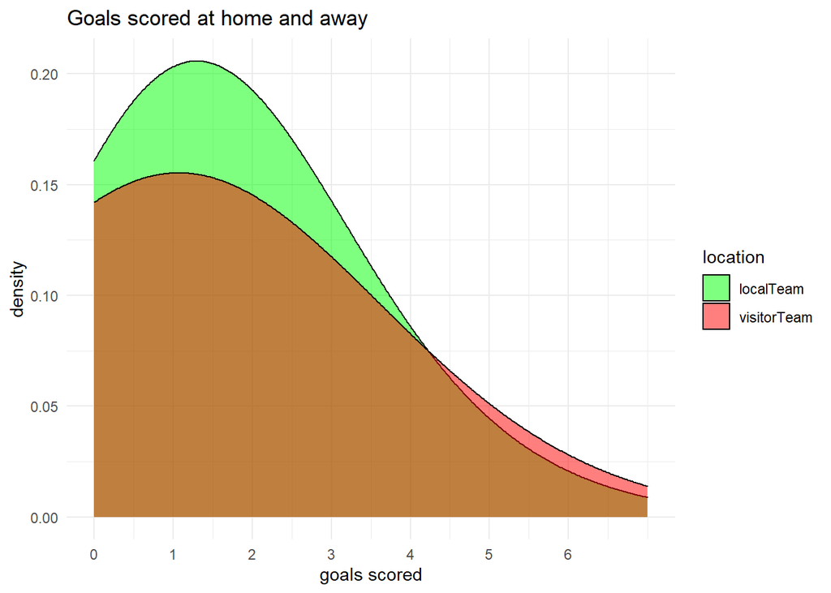

```r
data_melted %>%
  ggplot(., aes(x = g_for, fill = location)) +
  geom_density(adjust = 8, alpha = 0.5) +
  scale_fill_manual(values = c("green", "red")) +
  scale_x_continuous(breaks = 0:6) +
  labs(title = "Goals scored at home and away",
       x = "goals scored",
       y = "density") +
  theme_minimal()
```

It is evident that the home team tends to score more than the visiting one. Also both charts look like a Poisson distribution. For the home team we can take the average number of goals scored per match as the mean of a Poisson distribution and we can see how well the previous graph fits a simulated Poisson process.

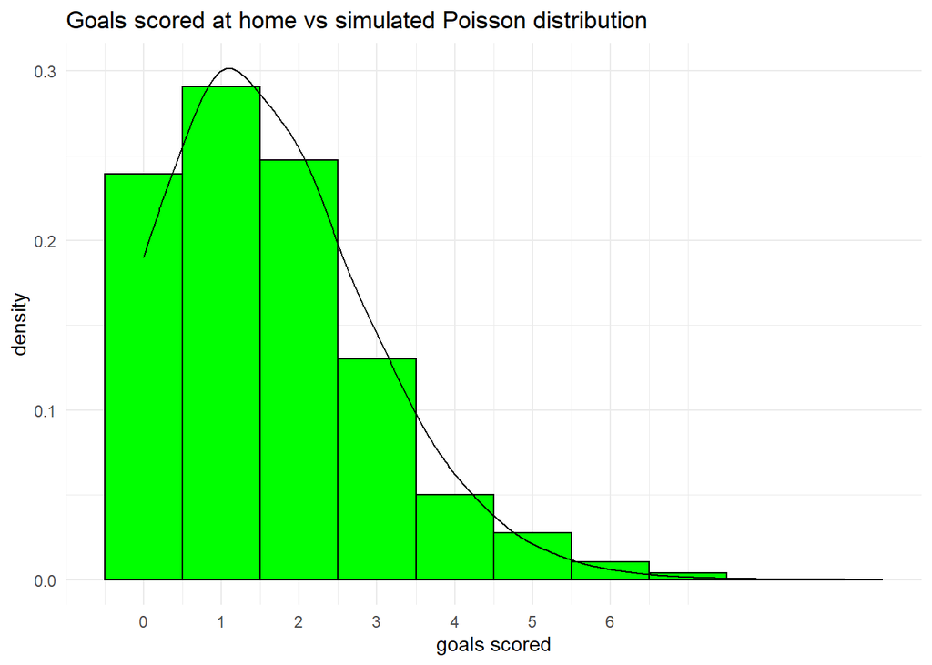

```r
p1 <- data_melted %>%
  filter( location == "localTeam") %>%
  ggplot(., aes(x = g_for)) +
  geom_histogram(aes(y=..density..),fill= "green", binwidth=1, color = 1) +
  scale_fill_manual(values = c("green")) +
  scale_x_continuous(breaks = 0:6) +
  labs(title = "Goals scored at home vs simulated Poisson distribution",
       x = "goals scored",
       y = "density") +
  theme_minimal() +
  theme(legend.position = "none")

local_team_data <- data_melted %>%
  filter( location == "localTeam")

simulated_poisson <- data.frame(dist = rpois(100000, mean(local_team_data$localGoals)))

p1 + geom_density(data = simulated_poisson, aes(x = dist),
                  fill = NA, adjust = 8, alpha = 0.2)
```

Similarly one can conclude that the goals scored by the visiting team also follow a Poisson process but with a different mean.

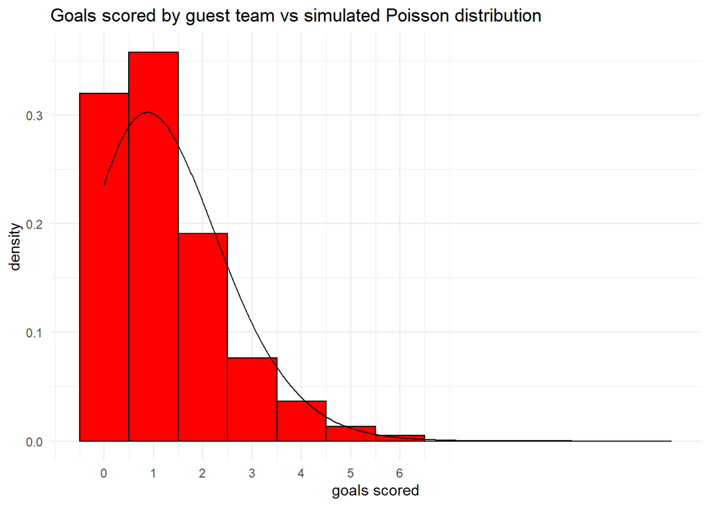

```r
p1 <- data_melted %>%
  filter( location == "visitorTeam") %>%
  ggplot(., aes(x = g_for)) +
  geom_histogram(aes(y=..density..),fill= "red", binwidth=1, color = 1) +
  scale_fill_manual(values = c("red")) +
  scale_x_continuous(breaks = 0:6) +
  labs(title = "Goals scored by guest team vs simulated Poisson distribution",
       x = "goals scored",
       y = "density") +
  theme_minimal() +
  theme(legend.position = "none")

visitor_team_data <- data_melted %>%
  filter( location == "visitorTeam")

simulated_poisson <- data.frame(dist = rpois(100000, mean(visitor_team_data$visitorGoals)))

p1 + geom_density(data = simulated_poisson, aes(x = dist),
                  fill = NA, adjust = 8, alpha = 0.2)
```

Hence, the probability of team i scoring x goals against team j can be estimated by Poisson distribution:
$$P(x_i=x) = \frac{\alpha^x_ie^{−\alpha_i}}{x!}$$

# Maher’s Poisson Model

In 1982 Maher proposed that the goals scored by each team can be modeled by two independent Poisson variables - $X_{ij}$ and $Y_{ij}$, where $i$ is the home team and $j$ is the visiting one. In particular the model suggests that:

$$X_{ij} \sim Poisson(\alpha_i\beta_j)$$

$$Y_{ij}\sim Poisson(\gamma_i\delta_j)$$
where $\alpha$ is an estimate of each team’s attack strength and $\beta_j$ is each team’s defense weakness parameter when playing away. Similarly $\gamma$ and $\delta$ are measures of the team’s attack and defense when playing away and at home repectivley. The model also assumes that the scores of the two teams are independent.

In what follows we calculate the four parameters for each team following the iterative approach proposed by Maher.

We start by Calculating alpha and beta based on “home scores”. Results after the first iteration:

```r
x_balanced <- x %>%
  group_by(local_team_index,visitor_team_index) %>%
  summarise(localGoals = mean(localGoals),
        visitorGoals = mean(visitorGoals))
Sx <- sum(x_balanced$localGoals)
local <- x_balanced %>%
  group_by(local_team_index) %>%
  summarise(localGoals_local = sum(localGoals),
            alpha = sum(localGoals)/sqrt(Sx))
visitor <- x_balanced %>%
  group_by(visitor_team_index) %>%
  summarise(localGoals_visitor = sum(localGoals),
            beta = sum(localGoals)/sqrt(Sx))

it_data <- left_join(local, visitor, by = c("local_team_index" = "visitor_team_index"))

for (i in 1:nrow(it_data)){
  it_data$beta[i] <- it_data$localGoals_visitor[i]/(sum(it_data$alpha)- it_data$alpha[i])
}

for (i in 1:nrow(it_data)){
  it_data$alpha[i] <- it_data$localGoals_local[i]/(sum(it_data$beta)- it_data$beta[i])
}

head(it_data)
```

| local_team_index | localGoals_local | alpha | localGoals_visitor | beta |
| --- | --- | --- | --- | --- |
| 1 | 25.5 | 0.9104267 | 34.0 | 1.252979 |
| 2 | 29.0 | 1.0515897 | 45.5 | 1.684528 |
| 3 | 70.0 | 2.4664259 | 22.5 | 0.880675 |
| 4 | 17.0 | 0.6195434 | 50.0 | 1.822262 |
| 5 | 39.5 | 1.4200246 | 38.5 | 1.445405 |
| 6 | 26.0 | 0.9283055 | 34.0 | 1.253802 |

Results after the second iteration are very close to the earlier one.

```r
for (i in 1:nrow(it_data)){
  it_data$beta[i] <- it_data$localGoals_visitor[i]/(sum(it_data$alpha)- it_data$alpha[i])
}

for (i in 1:nrow(it_data)){
  it_data$alpha[i] <- it_data$localGoals_local[i]/(sum(it_data$beta)- it_data$beta[i])
}
head(it_data)
```

| local_team_index | localGoals_local | alpha | localGoals_visitor | beta |
| --- | --- | --- | --- | --- |
| 1 | 25.5 | 0.9104265 | 34.0 | 1.2528521 |
| 2 | 29.0 | 1.0516266 | 45.5 | 1.6853777 |
| 3 | 70.0 | 2.4663361 | 22.5 | 0.8795219 |
| 4 | 17.0 | 0.6195603 | 50.0 | 1.8228907 |
| 5 | 39.5 | 1.4200519 | 38.5 | 1.4458204 |
| 6 | 26.0 | 0.9283053 | 34.0 | 1.2536781 |

The process continues until the the estimated $\alpha$ and $\beta$ stop changing and converge to their true values.

```r
it_data$alpha_prev <- 0
it_data$beta_prev <- 0
counter <- 2
while(identical(round(it_data$alpha_prev,6),round(it_data$alpha,6))==FALSE)
{
it_data$alpha_prev <- it_data$alpha
it_data$beta_prev <- it_data$beta
for (i in 1:nrow(it_data)){
  it_data$beta[i] <- it_data$localGoals_visitor[i]/(sum(it_data$alpha)- it_data$alpha[i])
}

for (i in 1:nrow(it_data)){
  it_data$alpha[i] <- it_data$localGoals_local[i]/(sum(it_data$beta)- it_data$beta[i])
}
it_data$alpha_prev <- it_data$alpha
it_data$beta_prev <- it_data$beta
counter <- sum(counter, 1)
}
head(it_data)
```

| local_team_index | localGoals_local | alpha | localGoals_visitor | beta | alpha_prev | beta_prev |
| --- | --- | --- | --- | --- | --- | --- |
| 1 | 25.5 | 0.9104265 | 34.0 | 1.2528518 | 0.9104265 | 1.2528518 |
| 2 | 29.0 | 1.0516267 | 45.5 | 1.6853796 | 1.0516267 | 1.6853796 |
| 3 | 70.0 | 2.4663358 | 22.5 | 0.8795186 | 2.4663358 | 0.8795186 |
| 4 | 17.0 | 0.6195603 | 50.0 | 1.8228913 | 0.6195603 | 1.8228913 |
| 5 | 39.5 | 1.4200520 | 38.5 | 1.4458215 | 1.4200520 | 1.4458215 |
| 6 | 26.0 | 0.9283053 | 34.0 | 1.2536777 | 0.9283053 | 1.2536777 |

```r
print(paste0("Number of iterations: " , counter))
```

```
## [1] "Number of iterations: 3"
```

Only after three iterations the results converge and so these are our true values for $\alpha$ - attack straight when playing at home and $\beta$ - weakness of defense when playing away. Ranking the teams just based on skill($\alpha$ / $\beta$ ) gives results close to the original ranking.

```r
alpha <- it_data$alpha
beta <- it_data$beta
teams$attack <- alpha
teams$defence <- beta
#teams <- select(teams,-alpha,-beta)
game_statistics_mod4 <- left_join(game_statistics,teams, by = c("team"))
game_statistics_mod4 <- game_statistics_mod4 %>%
  mutate(skill = attack*(1/defence)) %>%
  arrange(desc(skill))
head(game_statistics_mod4)
```

| team | W | L | D | GF | GA | GD | Pts | ranking | team index | attack | defence | skill |
| --- | --- | --- | --- | --- | --- | --- | --- | --- | --- | --- | --- | --- |
| Barcelona | 56 | 5 | 15 | 215 | 66 | 149 | 183 | 1 | 3 | 2.4663358 | 0.8795186 | 2.804188 |
| Atletico de Madrid | 46 | 11 | 19 | 128 | 49 | 79 | 157 | 3 | 8 | 1.5856492 | 0.5668321 | 2.797388 |
| Real Madrid | 51 | 9 | 16 | 200 | 85 | 115 | 169 | 2 | 15 | 2.1957264 | 1.0250346 | 2.142100 |
| Villarreal | 37 | 22 | 17 | 113 | 83 | 30 | 128 | 5 | 20 | 1.4318608 | 0.9768321 | 1.465821 |
| Real Sociedad | 33 | 29 | 14 | 125 | 112 | 13 | 113 | 7 | 7 | 1.6779537 | 1.2513955 | 1.340866 |
| Getafe | 15 | 13 | 10 | 42 | 33 | 9 | 55 | 18 | 23 | 0.9114906 | 0.7370005 | 1.236757 |

We repeat the same calculations for gamma and delta based on “visitor scores”. Results after the first iteration:

```r
x_balanced <- x %>%
  group_by(local_team_index,visitor_team_index) %>%
  summarise(localGoals = mean(localGoals),
        visitorGoals = mean(visitorGoals))
Sy <- sum(x_balanced$visitorGoals)
local <- x_balanced %>%
  group_by(local_team_index) %>%
  summarise(visitorGoals_local = sum(visitorGoals),
            gamma = sum(visitorGoals)/sqrt(Sy))
visitor <- x_balanced %>%
  group_by(visitor_team_index) %>%
  summarise(visitorGoals_visitor = sum(visitorGoals),
            delta = sum(visitorGoals)/sqrt(Sy))

it_data2 <- left_join(local, visitor, by = c("local_team_index" = "visitor_team_index"))

for (i in 1:nrow(it_data2)){
  it_data2$delta[i] <- it_data2$visitorGoals_visitor[i]/(sum(it_data2$gamma)- it_data2$gamma[i])
}

for (i in 1:nrow(it_data2)){
  it_data2$gamma[i] <- it_data2$visitorGoals_local[i]/(sum(it_data2$delta)- it_data2$delta[i])
}

head(it_data2)
```

| local_team_index | visitorGoals_local | gamma | visitorGoals_visitor | delta |
| --- | --- | --- | --- | --- |
| 1 | 28.5 | 1.1520383 | 15.5 | 0.6683341 |
| 2 | 31.0 | 1.2609722 | 19.0 | 0.8228893 |
| 3 | 15.5 | 0.6768779 | 59.5 | 2.5078381 |
| 4 | 32.0 | 1.2880860 | 13.0 | 0.5640323 |
| 5 | 19.5 | 0.8058687 | 28.5 | 1.2096043 |
| 6 | 38.0 | 1.5381251 | 16.0 | 0.7016916 |

Results after second iteration.

```r
for (i in 1:nrow(it_data2)){
  it_data2$delta[i] <- it_data2$visitorGoals_visitor[i]/(sum(it_data2$gamma)- it_data2$gamma[i])
}

for (i in 1:nrow(it_data2)){
  it_data2$gamma[i] <- it_data2$visitorGoals_local[i]/(sum(it_data2$delta)- it_data2$delta[i])
}

head(it_data2)
```

| local_team_index | visitorGoals_local | gamma | visitorGoals_visitor | delta |
| --- | --- | --- | --- | --- |
| 1 | 28.5 | 1.1520081 | 15.5 | 0.6675753 |
| 2 | 31.0 | 1.2609412 | 19.0 | 0.8221756 |
| 3 | 15.5 | 0.6769816 | 59.5 | 2.5112358 |
| 4 | 32.0 | 1.2880486 | 13.0 | 0.5632020 |
| 5 | 19.5 | 0.8058671 | 28.5 | 1.2094452 |
| 6 | 38.0 | 1.5380741 | 16.0 | 0.7007627 |

Again the results converge after the third iteration and these are our true values for - attack straight when playing at away and - weakness of defense when playing at home.

```r
it_data2$delta_prev <- 0
it_data2$gamma_prev <- 0
counter <- 2
while(identical(round(it_data2$delta_prev,6),round(it_data2$delta,6))==FALSE)
{
it_data2$delta_prev <- it_data2$delta
it_data2$gamma_prev <- it_data2$gamma
for (i in 1:nrow(it_data2)){
  it_data2$delta[i] <- it_data2$visitorGoals_visitor[i]/(sum(it_data2$gamma)- it_data2$gamma[i])
}

for (i in 1:nrow(it_data2)){
  it_data2$gamma[i] <- it_data2$visitorGoals_local[i]/(sum(it_data2$delta)- it_data2$delta[i])
}
it_data2$delta_prev <- it_data2$delta
it_data2$gamma_prev <- it_data2$gamma
counter <- sum(counter, 1)
}



head(it_data2)
```

| local_team_index | visitorGoals_local | gamma | visitorGoals_visitor | delta | delta_prev | gamma_prev |
| --- | --- | --- | --- | --- | --- | --- |
| 1 | 28.5 | 1.1520080 | 15.5 | 0.6675738 | 0.6675738 | 1.1520080 |
| 2 | 31.0 | 1.2609412 | 19.0 | 0.8221736 | 0.8221736 | 1.2609412 |
| 3 | 15.5 | 0.6769818 | 59.5 | 2.5112442 | 2.5112442 | 0.6769818 |
| 4 | 32.0 | 1.2880485 | 13.0 | 0.5632005 | 0.5632005 | 1.2880485 |
| 5 | 19.5 | 0.8058670 | 28.5 | 1.2094439 | 1.2094439 | 0.8058670 |
| 6 | 38.0 | 1.5380740 | 16.0 | 0.7007603 | 0.7007603 | 1.5380740 |

```r
print(paste0("Number of iterations: ",counter))
```

```
## [1] "Number of iterations: 3"
```

We compare the actual games outcomes with the ones predicted by the model.

```r
verify_model <- left_join(it_data,it_data2, by = "local_team_index")
verify_model <- verify_model[,c(1,3,5,9,11)]
verify_model <- verify_model %>%
  rename(team_index = local_team_index)
x_updated <- left_join(x,verify_model[,c("team_index","alpha","gamma")], by = c("local_team_index" = "team_index"))
x_updated <- left_join(x_updated,verify_model[,c("team_index","beta","delta")], by = c("visitor_team_index" = "team_index"))
x_updated <- x_updated %>%
  mutate( x_score_pred = round(alpha*beta,0),
          y_score_pred = round(delta*gamma,0))

head(x_updated)
```

| localGoals | visitorGoals | local_team_index | visitor_team_index | alpha | gamma | beta | delta | x_score_pred | y_score_pred |
| --- | --- | --- | --- | --- | --- | --- | --- | --- | --- |
| 1 | 1 | 1 | 13 | 0.9104265 | 1.1520080 | 2.0217492 | 0.7459748 | 2 | 1 |
| 2 | 1 | 2 | 14 | 1.0516267 | 1.2609412 | 1.2662050 | 1.1976528 | 1 | 2 |
| 6 | 2 | 3 | 11 | 2.4663358 | 0.6769818 | 1.4361038 | 1.1465297 | 4 | 1 |
| 1 | 1 | 4 | 20 | 0.6195603 | 1.2880485 | 0.9768321 | 1.1303725 | 1 | 1 |
| 6 | 4 | 5 | 12 | 1.4200520 | 0.8058670 | 1.0540663 | 0.9578120 | 1 | 1 |
| 2 | 1 | 6 | 19 | 0.9283053 | 1.5380740 | 1.2450600 | 1.0190937 | 1 | 2 |

Ranking the teams based on the predicted games outcomes.

```r
melt_results2 <- function(results_df) {
  results_df %>%
    # select only relevant columns
    select(local_team_index, visitor_team_index, x_score_pred, y_score_pred,index) %>%
    gather(location, team,   -x_score_pred, -y_score_pred,-index) %>%
    # calculate goals for/against the team
    mutate(g_for = case_when(
      location == "local_team_index" ~ x_score_pred,
      location == "visitor_team_index" ~ y_score_pred
    )) %>%
    mutate(g_ag = case_when(
      location == "local_team_index" ~ y_score_pred,
      location == "visitor_team_index" ~ x_score_pred
    ))
}

x_updated$index <- 1:nrow(x_updated)

x_updated_melted <- x_updated %>%
  melt_results2()


it_mod_game_statistics <- x_updated_melted %>%
  mutate(win = ifelse(g_for > g_ag, 1,0),
         loss = ifelse(g_for < g_ag, 1,0),
         draw = ifelse(g_for == g_ag, 1,0))

it_mod_game_statistics <- it_mod_game_statistics %>%
  group_by(team) %>%
  summarise ( W_pred = sum(win),
           L_pred = sum (loss),
           D_pred = sum(draw),
           GF_pred = sum(g_for),
           GA_pred = sum(g_ag),
           GD_pred = GF_pred - GA_pred,
           Pts_pred = 3*W_pred + 1*D_pred
           ) %>%
  arrange(desc(Pts_pred))

# it_mod_game_statistics <- x_updated_melted %>%
#   mutate(win = ifelse(g_for > g_ag, 1,0),
#          loss = ifelse(g_for < g_ag, 1,0),
#          draw = ifelse(g_for == g_ag, 1,0))
#
# it_mod_game_statistics <- it_mod_game_statistics %>%
#   group_by(team) %>%
#   summarise ( W = sum(win),
#            L = sum (loss),
#            D = sum(draw),
#            GF = sum(g_for),
#            GA = sum(g_ag),
#            GD = GF - GA,
#            Pts = 3*W + 1*D
#            ) %>%
#   arrange(desc(Pts))

it_mod_game_statistics$team <- as.character(it_mod_game_statistics$team)

it_mod_game_statistics <- left_join(it_mod_game_statistics, teams[,c(1,2)], by= c("team"="team index"))
it_mod_game_statistics <- it_mod_game_statistics %>%
  rename(team_number = team,
         team = team.y)

it_mod_game_statistics$pred_ranking <- 1:nrow(it_mod_game_statistics)

it_mod_game_statistics <- left_join(it_mod_game_statistics, game_statistics[,c(1,9)], "team")

it_mod_game_statistics
```

| team_number | W_pred | L_pred | D_pred | GF_pred | GA_pred | GD_pred | Pts_pred | team | pred_ranking | ranking |
| --- | --- | --- | --- | --- | --- | --- | --- | --- | --- | --- |
| 3 | 71 | 0 | 5 | 219 | 71 | 148 | 218 | Barcelona | 1 | 1 |
| 15 | 67 | 8 | 1 | 199 | 90 | 109 | 202 | Real Madrid | 2 | 2 |
| 8 | 62 | 0 | 14 | 143 | 55 | 88 | 200 | Atletico de Madrid | 3 | 3 |
| 10 | 41 | 16 | 19 | 125 | 104 | 21 | 142 | Valencia | 4 | 6 |
| 20 | 35 | 12 | 29 | 115 | 88 | 27 | 134 | Villarreal | 5 | 5 |
| 7 | 36 | 18 | 22 | 126 | 108 | 18 | 130 | Real Sociedad | 6 | 7 |
| 5 | 30 | 20 | 26 | 118 | 109 | 9 | 116 | Sevilla | 7 | 4 |
| 14 | 23 | 20 | 33 | 103 | 104 | -1 | 102 | Eibar | 8 | 9 |
| 9 | 23 | 28 | 25 | 113 | 124 | -11 | 94 | Celta de Vigo | 9 | 13 |
| 19 | 15 | 22 | 39 | 91 | 101 | -10 | 84 | Atletico de Bilbao | 10 | 8 |

[output cut: 13 more lines]

The top three teams are ranked correctly by the model but there are some mismatches further down the chart. Valencia for example was ranked 4th by the model while in reality it held the sixth position in the original ranking. Nevertheless the model performed well as most teams were just one position up or down from the original ranking.

# Maher’s Model - A Simplified Version

After looking into the significance of each of the four parameters Maher concludes that the home advantage applies with equal effect to all teams’ scoring power. Hence he proposes a simplified model with the following parameters $\alpha_i$, $\beta_j$, $\gamma$, where the latter is the so-called home advantage.

Ultimately Maher arrives at the following Poisson model which takes into account the team’s attack, the defense of its opponent and if the team is playing at home. As we saw earlier, in general football teams tend to perform better at home, so we want to factor that in.

$$X_{ij} \sim Poisson(\alpha_i\beta_j\gamma)$$

$$Y_{ij}\sim Poisson(\alpha_j\beta_i)$$
Due to the independence of $X_i,_j$ and $Y_i,_j$ we are interested in the following model:

$$P(X_i,_j = x, Y_i,_j = y) = \frac{\lambda e^{-\lambda}}{x!}\frac{\mu e^{-\mu}}{x!}$$
where

$$\lambda = \alpha_i\beta_j\gamma$$
$$\mu = \alpha_j\beta_i$$
The likelihood function of the Poisson model is given by

$$L(\alpha_i,\beta_i,\gamma,i = 1,2,...,n) = \prod_{k=1}^{N} e^{-\lambda_k}\lambda_k^{x_k} e^{-\mu_k}\mu_k^{x_k}$$
and we’d like to find the set of parameters that will minimize it.

In what follows we apply a constraint optimization algorithm where we are using the following constraint:

$$\sum_{i=1}^n\frac{\alpha_i}{n}=1$$
or the equivalent

$$ln(\sum_{i=1}^n\frac{\alpha_i}{n}=1) = 0$$

```r
x = data[,c(5:8)]
n = n_distinct(x$localTeam)
teams <- matrix(c(unique(x$localTeam),1:n), nrow = n)
teams <- as.data.frame(teams)
x <- left_join(x,teams, by = c("localTeam" = "V1"))
x <- left_join(x,teams, by = c("visitorTeam" = "V1"))

x <- x %>%
  rename(local_team_index = V2.x,
         visitor_team_index = V2.y)
x <-x [,c(3:6)]

x <- as.data.table(x)

x$local_team_index <- as.integer(x$local_team_index)
x$visitor_team_index <- as.integer(x$visitor_team_index)

x <- as.data.table(x)

f_lambda = function(alfa, beta, gama){
  gama*alfa[x$local_team_index]*beta[x$visitor_team_index]
}

f_mu = function(alfa, beta, gama){
  beta[x$local_team_index]*alfa[x$visitor_team_index]
}

f_l = function(w) {
  alfa = w[1:n]
  beta = w[(n+1):(2*n)]
  gama = w[2*n+1]
  lambda = f_lambda(alfa, beta, gama)
  mu =     f_mu(alfa, beta, gama)

  - sum(x$localGoals * log(lambda) + x$visitorGoals * log(mu) - lambda - mu)
}

eq = function(w) {
  alfa = w[1:n]
  c(log(sum(alfa)/n))
}

w0 = rep(1, 2*n+1)
options(warn = -1)

suppressMessages(
S <- slsqp(w0, fn = f_l,
           heq = eq,
           control = list(xtol_rel = 1e-9, print_level = 0)
            )
)
S
```

```
## $par
##  [1] 0.7047161 0.7902357 2.0308545 0.5646186 1.1354731 0.7835834 1.2060606
##  [8] 1.1974115 1.0894378 1.1621212 0.9801410 0.8112950 0.7622612 0.9589854
## [15] 1.9070778 0.6724318 0.7552111 0.7734235 0.8973712 1.0744559 1.0170870
## [22] 0.8937945 0.8319521 1.2565258 1.4904154 0.7660501 1.7923524 1.1847218
## [29] 1.5914687 1.2446023 0.5442704 1.4249347 1.1419987 1.3730485 1.0019294
## [36] 2.0754782 1.1082266 0.9800376 1.1463419 1.6072383 1.0108828 1.0063126
## [43] 0.9161140 1.2779447 1.2485385 0.7081850 1.3232104
##
## $value
## [1] 1191.439
##
## $iter
## [1] 212
##
## $convergence
## [1] 4
##
## $message
## [1] "NLOPT_XTOL_REACHED: Optimization stopped because xtol_rel or xtol_abs (above) was reached."
```

We rank teams based on the combination of their attack and defense.

```r
alpha <- S$par[1:n]
beta <- S$par[(n+1):(2*n)]
gamma <- S$par[2*n+1]
teams$alpha <- alpha
teams$beta <- beta
teams <- teams %>%
  rename(team = V1,
         team_number = V2)

game_statistics_mod1 <- left_join(game_statistics,teams, by = c("team"))
game_statistics_mod1 <- game_statistics_mod1 %>%
  mutate(skill = alpha/beta) %>%
  arrange(desc(skill))

head(game_statistics_mod1)
```

| team | W | L | D | GF | GA | GD | Pts | ranking | team_number | alpha | beta | skill |
| --- | --- | --- | --- | --- | --- | --- | --- | --- | --- | --- | --- | --- |
| Barcelona | 56 | 5 | 15 | 215 | 66 | 149 | 183 | 1 | 3 | 2.0308545 | 0.7660501 | 2.651073 |
| Atletico de Madrid | 46 | 11 | 19 | 128 | 49 | 79 | 157 | 3 | 8 | 1.1974115 | 0.5442704 | 2.200031 |
| Real Madrid | 51 | 9 | 16 | 200 | 85 | 115 | 169 | 2 | 15 | 1.9070778 | 0.9800376 | 1.945923 |
| Getafe | 15 | 13 | 10 | 42 | 33 | 9 | 55 | 18 | 23 | 0.8319521 | 0.7081850 | 1.174767 |
| Villarreal | 37 | 22 | 17 | 113 | 83 | 30 | 128 | 5 | 20 | 1.0744559 | 0.9161140 | 1.172841 |
| Valencia | 35 | 27 | 14 | 121 | 103 | 18 | 119 | 6 | 10 | 1.1621212 | 1.1419987 | 1.017620 |

Note that some of the teams with low real life ranking like Getafe (18th position in the real ranking) have pretty high attack/defense scores. In Getafe’s case the higher predicted ranking is due to the strong defense of the team. Getaffe is actually the team with the least number of goals scored against them. However, this ranking doesn’t accounting for the home advantage and the actual games played.

Ranking teams based on the predicted games outcomes.

```r
x$local_team_index <- as.character(x$local_team_index)
x$visitor_team_index <- as.character(x$visitor_team_index)
x_updated <- left_join(x,teams[,c("team_number","alpha","beta")], by = c("local_team_index" = "team_number"))
x_updated <- left_join(x_updated,teams[,c("team_number","alpha","beta")], by = c("visitor_team_index" = "team_number"))
x_updated <- x_updated %>%
  mutate( x_score_pred = round(alpha.x*beta.y*gamma,0),
          y_score_pred = round(alpha.y*beta.x,0))

melt_results2 <- function(results_df) {
  results_df %>%
    # select only relevant columns
    select(local_team_index, visitor_team_index, x_score_pred, y_score_pred,index) %>%
    gather(location, team,   -x_score_pred, -y_score_pred,-index) %>%
    # calculate goals for/against the team
    mutate(g_for = case_when(
      location == "local_team_index" ~ x_score_pred,
      location == "visitor_team_index" ~ y_score_pred
    )) %>%
    mutate(g_ag = case_when(
      location == "local_team_index" ~ y_score_pred,
      location == "visitor_team_index" ~ x_score_pred
    ))
}

x_updated$index <- 1:nrow(x_updated)

x_updated_melted <- x_updated %>%
  melt_results2()


game_statistics_mod1 <- x_updated_melted %>%
  mutate(win = ifelse(g_for > g_ag, 1,0),
         loss = ifelse(g_for < g_ag, 1,0),
         draw = ifelse(g_for == g_ag, 1,0))

game_statistics_mod1 <- game_statistics_mod1 %>%
  group_by(team) %>%
  summarise ( W_pred = sum(win),
           L_pred = sum (loss),
           D_pred = sum(draw),
           GF_pred = sum(g_for),
           GA_pred = sum(g_ag),
           GD_pred = GF_pred - GA_pred,
           Pts_pred = 3*W_pred + 1*D_pred
           ) %>%
  arrange(desc(Pts_pred))

# game_statistics_mod1 <- x_updated_melted %>%
#   mutate(win = ifelse(g_for > g_ag, 1,0),
#          loss = ifelse(g_for < g_ag, 1,0),
#          draw = ifelse(g_for == g_ag, 1,0))
#
# game_statistics_mod1 <- game_statistics_mod1 %>%
#   group_by(team) %>%
#   summarise ( W_pred = sum(win),
#            L_pred = sum (loss),
#            D_pred = sum(draw),
#            GF_pred = sum(g_for),
#            GA_pred = sum(g_ag),
#            GD_pred = GF_pred - GA_pred,
#            Pts_pred = 3*W_pred + 1*D_pred
#            ) %>%
#   arrange(desc(Pts_pred))

game_statistics_mod1$team <- as.character(game_statistics_mod1$team)

game_statistics_mod1 <- left_join(game_statistics_mod1, teams[,c(1,2)], by= c("team"="team_number"))
game_statistics_mod1 <- game_statistics_mod1 %>%
  rename(team_number = team,
         team = team.y)

game_statistics_mod1$pred_ranking <- 1:nrow(game_statistics_mod1)

game_statistics_mod1 <- left_join(game_statistics_mod1, game_statistics[,c(1,9)], "team")

game_statistics_mod1
```

| team_number | W_pred | L_pred | D_pred | GF_pred | GA_pred | GD_pred | Pts_pred | team | pred_ranking | ranking |
| --- | --- | --- | --- | --- | --- | --- | --- | --- | --- | --- |
| 3 | 69 | 0 | 7 | 213 | 77 | 136 | 214 | Barcelona | 1 | 1 |
| 15 | 63 | 4 | 9 | 199 | 88 | 111 | 198 | Real Madrid | 2 | 2 |
| 8 | 50 | 0 | 26 | 128 | 54 | 74 | 176 | Atletico de Madrid | 3 | 3 |
| 7 | 39 | 16 | 21 | 128 | 105 | 23 | 138 | Real Sociedad | 4 | 7 |
| 10 | 38 | 15 | 23 | 120 | 99 | 21 | 137 | Valencia | 5 | 6 |
| 20 | 34 | 8 | 34 | 112 | 84 | 28 | 136 | Villarreal | 6 | 5 |
| 5 | 36 | 19 | 21 | 118 | 103 | 15 | 129 | Sevilla | 7 | 4 |
| 14 | 24 | 20 | 32 | 101 | 100 | 1 | 104 | Eibar | 8 | 9 |
| 9 | 24 | 33 | 19 | 108 | 127 | -19 | 91 | Celta de Vigo | 9 | 13 |
| 19 | 14 | 16 | 46 | 88 | 96 | -8 | 88 | Atletico de Bilbao | 10 | 8 |

[output cut: 13 more lines]

# Dixon-Coles Model

The Dixon-Coles model is very similar to the one described in the previous section. Dixon and Coles relaxed the assumption of independence between the scores of the two teams by introducing the following function:

$$\tau_\lambda,_\mu(x,y) = \begin{cases}
1-\lambda\mu\rho \qquad \qquad\ \text{if } x=y=0\\
1+\lambda\rho \qquad\qquad \text{if } x=0, y=1\\
1+\mu\rho \quad \quad\quad\ \ \ \ \text{if } x=1, y=0\\
1-\rho \qquad \quad \quad\quad\ \ \text{if } x=y=1\\
1 \qquad \qquad \qquad \qquad \ \text{otherwise}
\end{cases}$$
and proposed the enhanced model:
$$P(X_i,_j = x, Y_i,_j = y) = \tau_\lambda,_\mu(x,y)\frac{\lambda e^{-\lambda}}{x!}\frac{\mu e^{-\mu}}{x!}$$

The likelihood function of the model is given by

$$L(\alpha_i,\beta_i,\gamma,\rho,i = 1,2,...,n) = \prod_{k=1}^{N} \tau_{\lambda_k},_{\mu_k}(x,y)e^{-\lambda_k}\lambda_k^{x_k} e^{-\mu_k}\mu_k^{x_k}$$
In what follows we apply the same constraint optimization algorithm as before but including the new parameter rho.

```r
x$local_team_index <- as.integer(x$local_team_index)
x$visitor_team_index <- as.integer(x$visitor_team_index)

f_lambda = function(alfa, beta, gama){
  gama*alfa[x$local_team_index]*beta[x$visitor_team_index]
}

f_mu = function(alfa, beta, gama){
  beta[x$local_team_index]*alfa[x$visitor_team_index]
}

tau<- rep(0,nrow(x))

f_tau = function(lambda, mu, rho){
  for(i in 1:nrow(x)){
  if (x$localGoals[i]== 0 && x$visitorGoals[i] == 0) {
      tau[i] = 1-lambda[i]*mu[i]*rho
    } else if (x$localGoals[i]== 0 && x$visitorGoals[i] == 1) {
      tau[i] = 1+lambda[i]*rho
    } else if (x$localGoals[i]== 1 && x$visitorGoals[i] == 0) {
      tau[i] = 1+mu[i]*rho
    } else if (x$localGoals[i] == 1 && x$visitorGoals[i] == 1) {
      tau[i] = 1-rho
    } else {tau[i] = 1}
  }
  return(tau)}


f_l = function(w) {
  alfa = w[1:n]
  beta = w[(n+1):(2*n)]
  gama = w[2*n+1]
  rho = w[2*n+2]
  lambda = f_lambda(alfa, beta, gama)
  mu = f_mu(alfa, beta, gama)
  tau = f_tau(lambda, mu, rho)

  - sum(x$localGoals * log(lambda) + x$visitorGoals * log(mu) - lambda - mu + log(tau))
}

eq = function(w) {
  alfa = w[1:n]
  c(log(sum(alfa)/n))
}

w0 = c(rep(1, 2*n+1),0)
options(warn = -1)

suppressMessages(
S_DC <- slsqp(w0, fn = f_l,
           heq = eq,
           control = list(xtol_rel = 1e-9, print_level = 0)
            )
)
S_DC
```

```
## $par
##  [1]  0.704483147  0.790505888  2.030961750  0.564683719  1.135889884
##  [6]  0.783852158  1.206020943  1.197456984  1.089092319  1.162218426
## [11]  0.980153930  0.811296459  0.762434922  0.958931607  1.906897920
## [16]  0.672567622  0.754872640  0.773276286  0.897415500  1.074563989
## [21]  1.016763544  0.894087154  0.831573209  1.256731739  1.490941166
## [26]  0.766038154  1.792488242  1.184671402  1.591855297  1.244610859
## [31]  0.544100429  1.424827240  1.142060569  1.372876206  1.001736540
## [36]  2.075537039  1.108217741  0.980221828  1.146371276  1.606901708
## [41]  1.010676941  1.006425362  0.915972009  1.277750459  1.248770512
## [46]  0.708098207  1.323236587 -0.004599772
##
## $value
## [1] 1191.435
##
## $iter
## [1] 199
##
## $convergence
## [1] 4
##
## $message
## [1] "NLOPT_XTOL_REACHED: Optimization stopped because xtol_rel or xtol_abs (above) was reached."
```

Ranking the teams based on the newly calculated attack and defense parameters (rho and the home effect are not taken into account).

```r
home_adv <- S_DC$par[2*n+1]
rho_par <- S_DC$par[2*n+2]
alpha <- S_DC$par[1:n]
beta <- S_DC$par[(n+1):(2*n)]
teams$alpha <- alpha
teams$beta <- beta
game_statistics_mod2 <- left_join(game_statistics,teams, by = c("team"))
game_statistics_mod2 <- game_statistics_mod2 %>%
  mutate(skill = alpha/beta) %>%
  arrange(desc(skill))
head(game_statistics_mod2)
```

| team | W | L | D | GF | GA | GD | Pts | ranking | team_number | alpha | beta | skill |
| --- | --- | --- | --- | --- | --- | --- | --- | --- | --- | --- | --- | --- |
| Barcelona | 56 | 5 | 15 | 215 | 66 | 149 | 183 | 1 | 3 | 2.0309617 | 0.7660382 | 2.651254 |
| Atletico de Madrid | 46 | 11 | 19 | 128 | 49 | 79 | 157 | 3 | 8 | 1.1974570 | 0.5441004 | 2.200801 |
| Real Madrid | 51 | 9 | 16 | 200 | 85 | 115 | 169 | 2 | 15 | 1.9068979 | 0.9802218 | 1.945374 |
| Getafe | 15 | 13 | 10 | 42 | 33 | 9 | 55 | 18 | 23 | 0.8315732 | 0.7080982 | 1.174376 |
| Villarreal | 37 | 22 | 17 | 113 | 83 | 30 | 128 | 5 | 20 | 1.0745640 | 0.9159720 | 1.173141 |
| Valencia | 35 | 27 | 14 | 121 | 103 | 18 | 119 | 6 | 10 | 1.1622184 | 1.1420606 | 1.017650 |

The results are very similar to what we saw in the earlier models. The top teams have the highest attack/defence ratio with Getafe being somewhat of an outlier because of its storng deffence.

# Linear representation of the Dixon-Coles model

Previously we defined the following parameters:

$$\lambda = \alpha_i\beta_j\gamma$$

$$\mu = \alpha_j\beta_i$$

$$\tau_\lambda,_\mu(x,y) = \begin{cases}
1-\lambda\mu\rho \qquad \qquad\ \text{if } x=y=0\\
1+\lambda\rho \qquad\qquad \text{if } x=0, y=1\\
1+\mu\rho \quad \quad\quad\ \ \ \ \text{if } x=1, y=0\\
1-\rho \qquad \quad \quad\quad\ \ \text{if } x=y=1\\
1 \qquad \qquad \qquad \qquad \ \text{otherwise}
\end{cases}$$
Where $\alpha$ is an estimate of each team’s attack rating, $\beta_j$ is each teams defense parameter and $\gamma$ is the “home advantage”. $\tau$ was introduced as a way to capture the correlation between the score of the two playing teams.

We can reshape the above as follows:

$$ln(\lambda) = \alpha_i+\beta_j+\gamma$$

$$ln(\mu) = \alpha_j + \beta_i$$

$$ln(\tau_\lambda,_\mu(x,y)) = \begin{cases}
-ln(\lambda)-ln(\mu)-ln(\rho) \qquad \qquad\ \text{if } x=y=0\\
ln(\lambda) + ln(\rho) \qquad\qquad \text{if } x=0, y=1\\
ln(\mu) + ln(\rho) \quad \quad\quad\ \ \ \ \text{if } x=1, y=0\\
-ln(\rho) \qquad \quad \quad\quad\ \ \text{if } x=y=1\\
0 \qquad \qquad \qquad \qquad \ \text{otherwise}
\end{cases}$$
Where $\lambda$, $\beta$, $\gamma$ are the log-values of the previously defined parameters.

In what follows we apply the same constraint optimization algorithm as before to the same likelihood function but using the redefined parameters. The previously used constraint is now transformed into:

$$\sum_{i=1}^n\alpha_i=0$$
Applying the algorithm.

```r
f_lambda = function(alfa, beta, gama){
  gama + alfa[x$local_team_index] + beta[x$visitor_team_index]
}

f_mu = function(alfa, beta, gama){
  beta[x$local_team_index]+alfa[x$visitor_team_index]
}

tau<- rep(0,nrow(x))

f_tau = function(lambda, mu, rho){
  for(i in 1:nrow(x)){
  if (x$localGoals[i]== 0 && x$visitorGoals[i] == 0) {
      tau[i] = -lambda[i]-mu[i]-log(rho)
    } else if (x$localGoals[i]== 0 && x$visitorGoals[i] == 1) {
      tau[i] = lambda[i]+log(rho)
    } else if (x$localGoals[i]== 1 && x$visitorGoals[i] == 0) {
      tau[i] = mu[i]+log(rho)
    } else if (x$localGoals[i] == 1 && x$visitorGoals[i] == 1) {
      tau[i] = -log(rho)
    } else {tau[i] = 0}
  }
  return(tau)}


f_l = function(w) {
  alfa = w[1:n]
  beta = w[(n+1):(2*n)]
  gama = w[2*n+1]
  rho = w[2*n+2]
  lambda = f_lambda(alfa, beta, gama)
  mu = f_mu(alfa, beta, gama)
  tau = f_tau(lambda, mu, rho)

  - sum(x$localGoals * lambda + x$visitorGoals * mu - exp(lambda) - exp(mu) + tau)
}

eq = function(w) {
  alfa = w[1:n]
  c(sum(alfa))
}

w0 = c(rep(0, 2*n+1),1)
options(warn = -1)

suppressMessages(
S_DC2 <- slsqp(w0, fn = f_l,
           heq = eq,
           control = list(xtol_rel = 1e-9, print_level = 0, maxeval = 1000)
            )
)
S_DC2
```

```
## $par
##  [1] -1.922570e-01 -2.080045e-01  7.308706e-01 -4.742269e-01  1.254348e-01
##  [6] -2.362058e-01  2.426301e-01  1.926136e-01  1.783600e-01  1.900390e-01
## [11]  5.078074e-02 -1.770273e-01 -2.379759e-01  9.526389e-03  6.802136e-01
## [16] -4.111052e-01 -1.494058e-01 -1.879286e-01 -7.810499e-02  8.559432e-02
## [21]  8.502930e-02 -1.331500e-01 -8.570030e-02  1.735929e-01  3.207798e-01
## [26] -2.718963e-01  5.404987e-01  1.797246e-01  4.027137e-01  2.043620e-01
## [31] -4.405584e-01  3.470544e-01  1.189039e-01  3.092641e-01  6.940130e-04
## [36]  6.974448e-01  8.988768e-02 -7.782557e-02  8.279044e-02  4.718327e-01
## [41]  2.108905e-02 -3.810288e-02 -9.829237e-02  2.465020e-01  1.684583e-01
## [46] -3.172160e-01  2.584536e-01  6.049211e+09
##
## $value
## [1] 997.7632
##
## $iter
## [1] 252
##
## $convergence
## [1] 4
##
## $message
## [1] "NLOPT_XTOL_REACHED: Optimization stopped because xtol_rel or xtol_abs (above) was reached."
```

```r
home_adv <- S_DC2$par[2*n+1]
rho_par <- S_DC2$par[2*n+2]
alpha <- S_DC2$par[1:n]
beta <- S_DC2$par[(n+1):(2*n)]
teams$attack <- alpha
teams$defence <- beta
#teams <- select(teams,-alpha,-beta)
game_statistics_mod3 <- left_join(game_statistics,teams, by = c("team"))
game_statistics_mod3 <- game_statistics_mod3 %>%
  mutate(skill = exp(attack-defence)) %>%
  arrange(desc(skill))
head(game_statistics_mod3)
```

| team | W | L | D | GF | GA | GD | Pts | ranking | team_number | alpha | beta | attack | defence | skill |
| --- | --- | --- | --- | --- | --- | --- | --- | --- | --- | --- | --- | --- | --- | --- |
| Barcelona | 56 | 5 | 15 | 215 | 66 | 149 | 183 | 1 | 3 | 2.0309617 | 0.7660382 | 0.73087056 | -0.27189634 | 2.725813 |
| Real Madrid | 51 | 9 | 16 | 200 | 85 | 115 | 169 | 2 | 15 | 1.9068979 | 0.9802218 | 0.68021360 | -0.07782557 | 2.134088 |
| Atletico de Madrid | 46 | 11 | 19 | 128 | 49 | 79 | 157 | 3 | 8 | 1.1974570 | 0.5441004 | 0.19261363 | -0.44055840 | 1.883576 |
| Getafe | 15 | 13 | 10 | 42 | 33 | 9 | 55 | 18 | 23 | 0.8315732 | 0.7080982 | -0.08570030 | -0.31721602 | 1.260509 |
| Villarreal | 37 | 22 | 17 | 113 | 83 | 30 | 128 | 5 | 20 | 1.0745640 | 0.9159720 | 0.08559432 | -0.09829237 | 1.201880 |
| Valencia | 35 | 27 | 14 | 121 | 103 | 18 | 119 | 6 | 10 | 1.1622184 | 1.1420606 | 0.19003898 | 0.11890389 | 1.073726 |